# 458_Assignment_E3_A

[figure not shown]

## MSDS458 Research Assignment 02 - Part 1

**More Technical**: Throughout the notebook. This types of boxes provide more technical details and extra references about what you are seeing. They contain helpful tips, but you can safely skip them the first time you run through the code.

The CIFAR-10 dataset (Canadian Institute For Advanced Research) is a collection of images that are commonly used to train machine learning and computer vision algorithms. It is one of the most widely used datasets for machine learning research. The CIFAR-10 dataset contains 60,000 32x32 color images in 10 different classes. The 10 different classes represent airplanes, cars, birds, cats, deer, dogs, frogs, horses, ships, and trucks. There are 6,000 images of each class.

**The CIFAR-10 dataset**  
https://www.cs.toronto.edu/~kriz/cifar.html

## Imports

```python
import numpy as np
import pandas as pd
import datetime
from packaging import version

from sklearn.metrics import confusion_matrix, classification_report
from sklearn.metrics import accuracy_score
from sklearn.metrics import mean_squared_error as MSE
from sklearn.model_selection import train_test_split

import matplotlib.pyplot as plt
import seaborn as sns

import tensorflow as tf
from tensorflow import keras
from tensorflow.keras import models, layers
from tensorflow.keras.models import Sequential
from tensorflow.keras.layers import Conv2D, MaxPool2D, BatchNormalization, Dropout, Flatten, Dense
from tensorflow.keras.callbacks import ModelCheckpoint, EarlyStopping
from tensorflow.keras.preprocessing import image
from tensorflow.keras.utils import to_categorical
import tensorflow.keras.backend as k
```

```python
%matplotlib inline
np.set_printoptions(precision=3, suppress=True)
```

## Verify TensorFlow Version

```python
print("This notebook requires TensorFlow 2.0 or above")
print("TensorFlow version: ", tf.__version__)
assert version.parse(tf.__version__).release[0] >=2
```

```
This notebook requires TensorFlow 2.0 or above
TensorFlow version:  2.15.0
```

## Mount Google Drive to Colab Environment

```python
# from google.colab import drive
# drive.mount('/content/gdrive')
```

## EDA Functions

```python
def get_three_classes(x, y):
    def indices_of(class_id):
        indices, _ = np.where(y == float(class_id))
        return indices

    indices = np.concatenate([indices_of(0), indices_of(1), indices_of(2)], axis=0)

    x = x[indices]
    y = y[indices]

    count = x.shape[0]
    indices = np.random.choice(range(count), count, replace=False)

    x = x[indices]
    y = y[indices]

    y = tf.keras.utils.to_categorical(y)

    return x, y
```

```python
def show_random_examples(x, y, p):
    indices = np.random.choice(range(x.shape[0]), 10, replace=False)

    x = x[indices]
    y = y[indices]
    p = p[indices]

    plt.figure(figsize=(10, 5))
    for i in range(10):
        plt.subplot(2, 5, i + 1)
        plt.imshow(x[i])
        plt.xticks([])
        plt.yticks([])
        col = 'green' if np.argmax(y[i]) == np.argmax(p[i]) else 'red'
        plt.xlabel(class_names_preview[np.argmax(p[i])], color=col)
    plt.show()
```

## Research Assignment Reporting Functions

```python
def plot_history(history):
  losses = history.history['loss']
  accs = history.history['accuracy']
  val_losses = history.history['val_loss']
  val_accs = history.history['val_accuracy']
  epochs = len(losses)

  plt.figure(figsize=(16, 4))
  for i, metrics in enumerate(zip([losses, accs], [val_losses, val_accs], ['Loss', 'Accuracy'])):
    plt.subplot(1, 2, i + 1)
    plt.plot(range(epochs), metrics[0], label='Training {}'.format(metrics[2]))
    plt.plot(range(epochs), metrics[1], label='Validation {}'.format(metrics[2]))
    plt.legend()
  plt.show()

def display_training_curves(training, validation, title, subplot):
  ax = plt.subplot(subplot)
  ax.plot(training)
  ax.plot(validation)
  ax.set_title('model '+ title)
  ax.set_ylabel(title)
  ax.set_xlabel('epoch')
  ax.legend(['training', 'validation'])
```

```python
def print_validation_report(y_test, predictions):
    print("Classification Report")
    print(classification_report(y_test, predictions))
    print('Accuracy Score: {}'.format(accuracy_score(y_test, predictions)))
    print('Root Mean Square Error: {}'.format(np.sqrt(MSE(y_test, predictions))))
```

```python
def plot_confusion_matrix(y_true, y_pred):
    mtx = confusion_matrix(y_true, y_pred)
    fig, ax = plt.subplots(figsize=(16,12))
    sns.heatmap(mtx, annot=True, fmt='d', linewidths=.75,  cbar=False, ax=ax,cmap='Blues',linecolor='white')
    #  square=True,
    plt.ylabel('true label')
    plt.xlabel('predicted label')
```

## Loading cifar10 Dataset

The CIFAR-10 dataset consists of 60000 32x32 colour images in 10 classes, with 6000 images per class. There are 50000 training images and 10000 test images.

The dataset is divided into five training batches and one test batch, each with 10000 images. The test batch contains exactly 1000 randomly-selected images from each class. The training batches contain the remaining images in random order, but some training batches may contain more images from one class than another. Between them, the training batches contain exactly 5000 images from each class.

```python
(x_train, y_train), (x_test, y_test) = keras.datasets.cifar10.load_data()
```

## EDA Training and Test Datasets

- Imported 50000 examples for training and 10000 examples for test
- Imported 50000 labels for training and 10000 labels for test

```python
print('train_images:\t{}'.format(x_train.shape))
print('train_labels:\t{}'.format(y_train.shape))
print('test_images:\t\t{}'.format(x_test.shape))
print('test_labels:\t\t{}'.format(y_test.shape))
```

```
train_images:	(50000, 32, 32, 3)
train_labels:	(50000, 1)
test_images:		(10000, 32, 32, 3)
test_labels:		(10000, 1)
```

## Review Labels

```python
print("First ten labels training dataset:\n {}\n".format(y_train[0:10]))
print("This output the numeric label, need to convert to item description")
```

```
First ten labels training dataset:
 [[6]
 [9]
 [9]
 [4]
 [1]
 [1]
 [2]
 [7]
 [8]
 [3]]

This output the numeric label, need to convert to item description
```

## Plot Subset of Examples

```python
(train_images, train_labels),(test_images, test_labels)= tf.keras.datasets.cifar10.load_data()
```

```python
x_preview, y_preview = get_three_classes(train_images, train_labels)
x_preview, y_preview = get_three_classes(test_images, test_labels)
```

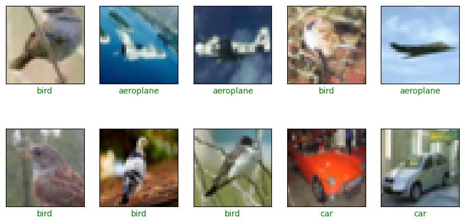

```python
class_names_preview = ['aeroplane', 'car', 'bird']

show_random_examples(x_preview, y_preview, y_preview)
```

## Preprocessing Data for Model Development

| Label | Class_ |
| --- | --- |
| 0 | airplane |
| 1 | automobile |
| 2 | bird |
| 3 | cat |
| 4 | deer |
| 5 | dog |
| 6 | frog |
| 7 | horse |
| 8 | ship |
| 9 | truck |

```python
class_names = ['airplane'
,'automobile'
,'bird'
,'cat'
,'deer'
,'dog'
,'frog'
,'horse'
,'ship'
,'truck']
```

## Create Validation Data Set

```python
x_train_split, x_valid_split, y_train_split, y_valid_split = train_test_split(x_train
                                                                              ,y_train
                                                                              ,test_size=.1
                                                                              ,random_state=42
                                                                              ,shuffle=True)
```

## Confirm Datasets {Train, Validation, Test}

```python
print(x_train_split.shape, x_valid_split.shape, x_test.shape)
```

```
(45000, 32, 32, 3) (5000, 32, 32, 3) (10000, 32, 32, 3)
```

## Rescale Examples {Train, Validation, Test}

1. Each element in each example is a pixel value
2. Pixel values range from 0 to 255
3. 0 = black
4. 255 = white

```python
x_train_norm = x_train_split/255
x_valid_norm = x_valid_split/255
x_test_norm = x_test/255
```

## Create the Model

[figure not shown]

## Experiment 3: Build CNN Model

CNN with 2 convolution/max pooling layers

```python
k.clear_session()
# Create the model
model = Sequential([
    Conv2D(filters=128, kernel_size=(3, 3), strides=(1, 1), activation='relu', input_shape=x_train_norm.shape[1:]),
    MaxPool2D((2, 2), strides=2),
    Conv2D(filters=256, kernel_size=(3, 3), strides=(1, 1), activation='relu'),
    MaxPool2D((2, 2), strides=2),
    Flatten(),
    Dense(units=384, activation='relu'),
    Dense(units=10, activation='softmax')
])
```

```python
model.summary()
```

```
Model: "sequential"
_________________________________________________________________
 Layer (type)                Output Shape              Param #
=================================================================
 conv2d (Conv2D)             (None, 30, 30, 128)       3584

 max_pooling2d (MaxPooling2  (None, 15, 15, 128)       0
 D)

 conv2d_1 (Conv2D)           (None, 13, 13, 256)       295168

 max_pooling2d_1 (MaxPoolin  (None, 6, 6, 256)         0
 g2D)

 flatten (Flatten)           (None, 9216)              0

 dense (Dense)               (None, 384)               3539328

 dense_1 (Dense)             (None, 10)                3850

=================================================================
Total params: 3841930 (14.66 MB)
Trainable params: 3841930 (14.66 MB)
Non-trainable params: 0 (0.00 Byte)
_________________________________________________________________
```

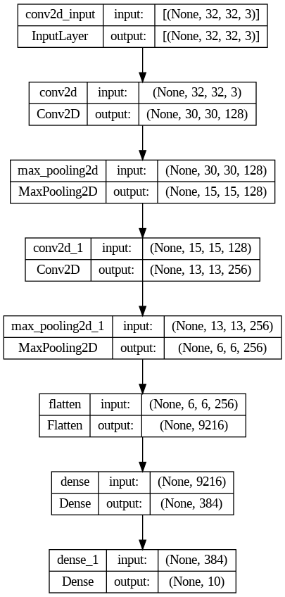

```python
tf.keras.utils.plot_model(model, "CIFAR10.png", show_shapes=True)
```

## Compiling the model

We also need to define a loss function. Think of this function as the difference between the predicted outputs and the actual outputs given in the dataset. This loss needs to be minimised in order to have a higher model accuracy. That's what the optimization algorithm essentially does - it minimises the loss during model training. For our multi-class classification problem, categorical cross entropy is commonly used.

Finally, we will use the accuracy during training as a metric to keep track of as the model trains.

**tf.keras.losses.SparseCategoricalCrossentropy**  
https://www.tensorflow.org/api_docs/python/tf/keras/losses/SparseCategoricalCrossentropy

```python
model.compile(optimizer='adam',
              loss=tf.keras.losses.SparseCategoricalCrossentropy(from_logits=False),
              metrics=['accuracy'])
```

## Training the model

**Module: tf.keras.callbacks**

**tf.keras.callbacks.EarlyStopping**  
https://www.tensorflow.org/api_docs/python/tf/keras/callbacks/EarlyStopping

**tf.keras.callbacks.ModelCheckpoint**  
https://www.tensorflow.org/api_docs/python/tf/keras/callbacks/ModelCheckpoint

```python
history = model.fit(x_train_norm
                    ,y_train_split
                    ,epochs=200
                    ,batch_size=64
                    ,validation_data=(x_valid_norm, y_valid_split)
                    ,callbacks=[
                     tf.keras.callbacks.ModelCheckpoint("CNN_model.h5",save_best_only=True,save_weights_only=False)
                     ,tf.keras.callbacks.EarlyStopping(monitor='val_accuracy', patience=3),
                    ]
                   )
```

## Evaluate the model

In order to ensure that this is not a simple "memorization" by the machine, we should evaluate the performance on the test set. This is easy to do, we simply use the `evaluate` method on our model.

```python
model = tf.keras.models.load_model("CNN_model.h5")
print(f"Test acc: {model.evaluate(x_test_norm, y_test)[1]:.3f}")
```

```
Test acc: 0.705
```

## Predictions

```python
preds = model.predict(x_test_norm)
print('shape of preds: ', preds.shape)
```

```
shape of preds:  (10000, 10)
```

## Plotting Performance Metrics

```python
history_dict = history.history
history_dict.keys()
```

```
dict_keys(['loss', 'accuracy', 'val_loss', 'val_accuracy'])
```

```python
history_df=pd.DataFrame(history_dict)
history_df.tail().round(3)
```

|  | loss | accuracy | val_loss | val_accuracy |
| --- | --- | --- | --- | --- |
| 7 | 0.262 | 0.909 | 1.052 | 0.721 |
| 8 | 0.187 | 0.937 | 1.109 | 0.733 |
| 9 | 0.138 | 0.953 | 1.363 | 0.711 |
| 10 | 0.113 | 0.962 | 1.312 | 0.722 |
| 11 | 0.096 | 0.967 | 1.508 | 0.712 |

## Plot Training Metrics (Loss and Accuracy)

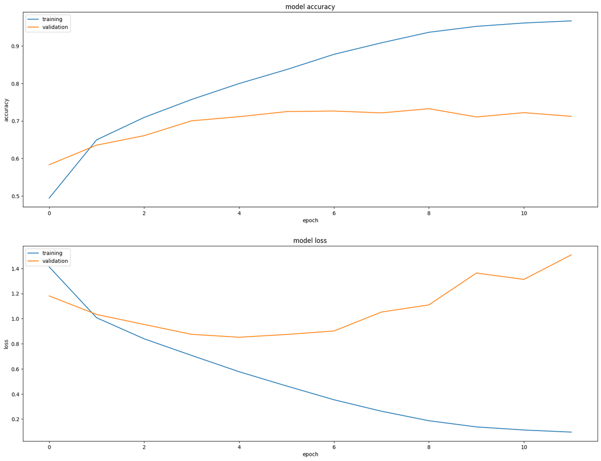

```python
plt.subplots(figsize=(16,12))
plt.tight_layout()
display_training_curves(history_df['accuracy'], history_df['val_accuracy'], 'accuracy', 211)
display_training_curves(history_df['loss'], history_df['val_loss'], 'loss', 212)
```

## Confusion matrices

Using both `sklearn.metrics`. Then we visualize the confusion matrix and see what that tells us.

```python
pred1= model.predict(x_test_norm)
pred1=np.argmax(pred1, axis=1)
```

```python
print_validation_report(y_test, pred1)
```

```
Classification Report
              precision    recall  f1-score   support

           0       0.66      0.82      0.73      1000
           1       0.76      0.88      0.82      1000
           2       0.67      0.50      0.57      1000
           3       0.60      0.44      0.50      1000
           4       0.67      0.63      0.65      1000
           5       0.60      0.66      0.63      1000
           6       0.67      0.86      0.76      1000
           7       0.76      0.76      0.76      1000
           8       0.87      0.74      0.80      1000
           9       0.80      0.76      0.78      1000

    accuracy                           0.70     10000
   macro avg       0.71      0.70      0.70     10000
weighted avg       0.71      0.70      0.70     10000

Accuracy Score: 0.7047
Root Mean Square Error: 2.31445457937718
```

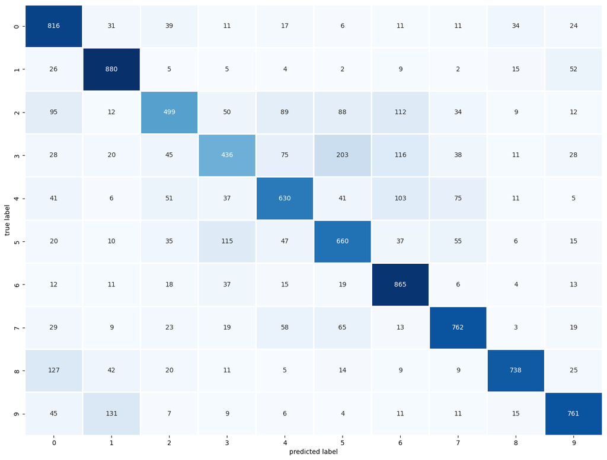

```python
plot_confusion_matrix(y_test,pred1)
```

## Load HDF5 Model Format

**tf.keras.models.load_model**  
https://www.tensorflow.org/api_docs/python/tf/keras/models/load_model

```python
model = tf.keras.models.load_model('CNN_model.h5')
```

```python
preds = model.predict(x_test_norm)
```

```python
preds.shape
```

```
(10000, 10)
```

## Predictions

```python
cm = sns.light_palette((260, 75, 60), input="husl", as_cmap=True)
```

```python
df = pd.DataFrame(preds[0:20], columns = ['airplane'
                                          ,'automobile'
                                          ,'bird'
                                          ,'cat'
                                          ,'deer'
                                          ,'dog'
                                          ,'frog'
                                          ,'horse'
                                          ,'ship'
                                          ,'truck'])
df.style.format("{:.2%}").background_gradient(cmap=cm)
```

|  | airplane | automobile | bird | cat | deer | dog | frog | horse | ship | truck |
| --- | --- | --- | --- | --- | --- | --- | --- | --- | --- | --- |
| 0 | 0.02% | 0.53% | 0.20% | 95.08% | 0.06% | 2.36% | 0.32% | 0.02% | 1.33% | 0.09% |
| 1 | 1.63% | 28.16% | 0.00% | 0.00% | 0.00% | 0.00% | 0.00% | 0.00% | 70.09% | 0.13% |
| 2 | 12.04% | 30.35% | 0.45% | 0.95% | 0.04% | 0.09% | 0.07% | 0.27% | 54.01% | 1.72% |
| 3 | 71.94% | 11.35% | 9.19% | 0.75% | 0.18% | 0.00% | 0.05% | 0.02% | 6.46% | 0.07% |
| 4 | 0.00% | 0.01% | 2.13% | 1.61% | 83.03% | 0.41% | 12.80% | 0.00% | 0.01% | 0.00% |
| 5 | 0.05% | 1.17% | 0.14% | 0.36% | 0.25% | 0.71% | 96.80% | 0.14% | 0.11% | 0.26% |
| 6 | 1.15% | 85.25% | 0.03% | 0.52% | 0.00% | 1.47% | 0.26% | 0.02% | 0.00% | 11.30% |
| 7 | 0.22% | 0.02% | 30.52% | 0.64% | 0.93% | 0.08% | 67.48% | 0.04% | 0.03% | 0.02% |
| 8 | 0.42% | 0.02% | 0.30% | 77.11% | 3.32% | 14.57% | 2.89% | 1.30% | 0.00% | 0.07% |
| 9 | 0.01% | 97.77% | 0.00% | 0.00% | 0.00% | 0.00% | 0.00% | 0.00% | 0.02% | 2.19% |
| 10 | 24.07% | 1.16% | 3.26% | 4.62% | 53.63% | 3.91% | 0.25% | 7.26% | 1.55% | 0.28% |
| 11 | 0.00% | 0.58% | 0.00% | 0.00% | 0.00% | 0.00% | 0.00% | 0.00% | 0.00% | 99.42% |
| 12 | 0.03% | 1.42% | 4.16% | 4.28% | 45.49% | 32.86% | 4.20% | 5.83% | 1.49% | 0.25% |
| 13 | 0.00% | 0.00% | 0.00% | 0.00% | 0.03% | 0.60% | 0.00% | 99.37% | 0.00% | 0.00% |
| 14 | 0.00% | 3.25% | 0.00% | 0.00% | 0.00% | 0.00% | 0.00% | 0.00% | 0.05% | 96.70% |
| 15 | 0.39% | 0.25% | 0.08% | 0.09% | 0.10% | 0.03% | 7.37% | 0.00% | 91.67% | 0.00% |
| 16 | 0.05% | 0.21% | 0.56% | 6.79% | 0.00% | 90.14% | 0.05% | 1.56% | 0.01% | 0.64% |
| 17 | 1.56% | 0.14% | 12.57% | 11.48% | 17.75% | 9.28% | 2.54% | 42.02% | 0.41% | 2.25% |
| 18 | 0.53% | 8.64% | 0.00% | 0.00% | 0.00% | 0.00% | 0.00% | 0.00% | 90.52% | 0.31% |
| 19 | 0.00% | 0.34% | 0.30% | 0.64% | 0.66% | 0.75% | 97.21% | 0.08% | 0.00% | 0.02% |

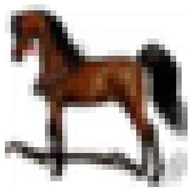

```python
(_,_), (test_images, test_labels) = tf.keras.datasets.cifar10.load_data()

img = test_images[2004]
img_tensor = image.img_to_array(img)
img_tensor = np.expand_dims(img_tensor, axis=0)

class_names = ['airplane'
,'automobile'
,'bird'
,'cat'
,'deer'
,'dog'
,'frog'
,'horse'
,'ship'
,'truck']

plt.imshow(img, cmap='viridis')
plt.axis('off')
plt.show()
```

```python
# Extracts the outputs of the top 8 layers:
layer_outputs = [layer.output for layer in model.layers[:8]]
# Creates a model that will return these outputs, given the model input:
activation_model = models.Model(inputs=model.input, outputs=layer_outputs)
```

```python
activations = activation_model.predict(img_tensor)
len(activations)
```

```
7
```

[figure not shown]

[figure not shown]

```python
# Create a model that outputs the activations from the first and second max pooling layers
layer_outputs = [layer.output for layer in model.layers if isinstance(layer, MaxPool2D)]


# Function to visualize activations
def visualize_activations(activations, layer_names):
    images_per_row = 8  # Number of images per row
    for layer_name, layer_activation in zip(layer_names, activations):
        n_features = layer_activation.shape[-1]  # Number of features in the feature map
        size = layer_activation.shape[1]  # Feature map size (height and width)

        # Tile the activation channels in this matrix
        n_cols = n_features // images_per_row
        display_grid = np.zeros((size * n_cols, images_per_row * size))

        for col in range(n_cols):
            for row in range(images_per_row):
                channel_image = layer_activation[0, :, :, col * images_per_row + row]
                # Post-process the feature to make it visually palatable
                channel_image -= channel_image.mean()
                if channel_image.std() != 0:
                    channel_image /= channel_image.std()
                channel_image *= 64
                channel_image += 128
                channel_image = np.clip(channel_image, 0, 255).astype('uint8')
                display_grid[col * size: (col + 1) * size,
                             row * size: (row + 1) * size] = channel_image

        # Display the grid
        scale = 1. / size
        plt.figure(figsize=(scale * display_grid.shape[1], scale * display_grid.shape[0]))
        plt.title(layer_name)
        plt.grid(False)
        plt.imshow(display_grid, aspect='auto', cmap='viridis')
        plt.show()

# Visualize the activations
layer_names = ['MaxPool2D_1', 'MaxPool2D_2']
visualize_activations(activations, layer_names)
```

```python
# Time Stamp
current_time = datetime.datetime.now()
formatted_time = current_time.strftime("%Y-%m-%d %H:%M:%S")

# Print the formatted time
print("Last Run:", formatted_time)
```

```
Last Run: 2024-06-11 17:29:09
```

```python
from google.colab import drive
drive.mount('/content/drive')
```

```python
!jupyter nbconvert --to html "/content/drive/MyDrive/Colab Notebooks/458_Assignment_E3_A.ipynb"
```